# Risk Factor Analysis

## Outcome Variable

**Outcome Variable:** sstunted

## Predictor Variables

**Intervention Variable:** meducyrs

**Adjustment Set:**

unadjusted

## Stratifying Variables

The analysis was stratified on these variable(s):

- agecat
- studyid
- country

## Data Summary

| agecat | studyid | country | meducyrs | sstunted | n_cell | n |
| --- | --- | --- | --- | --- | --- | --- |
| Birth | CMC-V-BCS-2002 | INDIA | High | 0 | 49 | 92 |
| Birth | CMC-V-BCS-2002 | INDIA | High | 1 | 2 | 92 |
| Birth | CMC-V-BCS-2002 | INDIA | Low | 0 | 16 | 92 |
| Birth | CMC-V-BCS-2002 | INDIA | Low | 1 | 0 | 92 |
| Birth | CMC-V-BCS-2002 | INDIA | Medium | 0 | 23 | 92 |
| Birth | CMC-V-BCS-2002 | INDIA | Medium | 1 | 2 | 92 |
| Birth | COHORTS | GUATEMALA | High | 0 | 177 | 842 |
| Birth | COHORTS | GUATEMALA | High | 1 | 1 | 842 |
| Birth | COHORTS | GUATEMALA | Low | 0 | 384 | 842 |
| Birth | COHORTS | GUATEMALA | Low | 1 | 7 | 842 |
| Birth | COHORTS | GUATEMALA | Medium | 0 | 270 | 842 |
| Birth | COHORTS | GUATEMALA | Medium | 1 | 3 | 842 |
| Birth | COHORTS | INDIA | High | 0 | 668 | 5216 |
| Birth | COHORTS | INDIA | High | 1 | 10 | 5216 |
| Birth | COHORTS | INDIA | Low | 0 | 1683 | 5216 |
| Birth | COHORTS | INDIA | Low | 1 | 73 | 5216 |
| Birth | COHORTS | INDIA | Medium | 0 | 2716 | 5216 |
| Birth | COHORTS | INDIA | Medium | 1 | 66 | 5216 |
| Birth | COHORTS | PHILIPPINES | High | 0 | 1156 | 3050 |
| Birth | COHORTS | PHILIPPINES | High | 1 | 13 | 3050 |
| Birth | COHORTS | PHILIPPINES | Low | 0 | 882 | 3050 |
| Birth | COHORTS | PHILIPPINES | Low | 1 | 18 | 3050 |
| Birth | COHORTS | PHILIPPINES | Medium | 0 | 966 | 3050 |
| Birth | COHORTS | PHILIPPINES | Medium | 1 | 15 | 3050 |
| Birth | EE | PAKISTAN | High | 0 | 5 | 239 |
| Birth | EE | PAKISTAN | High | 1 | 2 | 239 |
| Birth | EE | PAKISTAN | Low | 0 | 171 | 239 |
| Birth | EE | PAKISTAN | Low | 1 | 44 | 239 |
| Birth | EE | PAKISTAN | Medium | 0 | 16 | 239 |
| Birth | EE | PAKISTAN | Medium | 1 | 1 | 239 |

[output cut: 360 more lines]

The following strata were considered:

- agecat: 24 months, studyid: CMC-V-BCS-2002, country: INDIA
- agecat: 24 months, studyid: COHORTS, country: GUATEMALA
- agecat: 24 months, studyid: COHORTS, country: INDIA
- agecat: 24 months, studyid: COHORTS, country: PHILIPPINES
- agecat: 24 months, studyid: EE, country: PAKISTAN
- agecat: 24 months, studyid: GMS-Nepal, country: NEPAL
- agecat: 24 months, studyid: IRC, country: INDIA
- agecat: 24 months, studyid: LCNI-5, country: MALAWI
- agecat: 24 months, studyid: MAL-ED, country: BANGLADESH
- agecat: 24 months, studyid: MAL-ED, country: BRAZIL
- agecat: 24 months, studyid: MAL-ED, country: INDIA
- agecat: 24 months, studyid: MAL-ED, country: NEPAL
- agecat: 24 months, studyid: MAL-ED, country: PERU
- agecat: 24 months, studyid: MAL-ED, country: SOUTH AFRICA
- agecat: 24 months, studyid: MAL-ED, country: TANZANIA, UNITED REPUBLIC OF
- agecat: 24 months, studyid: NIH-Birth, country: BANGLADESH
- agecat: 24 months, studyid: NIH-Crypto, country: BANGLADESH
- agecat: 24 months, studyid: PROBIT, country: BELARUS
- agecat: 24 months, studyid: PROVIDE, country: BANGLADESH
- agecat: 24 months, studyid: TanzaniaChild2, country: TANZANIA, UNITED REPUBLIC OF
- agecat: 24 months, studyid: ZVITAMBO, country: ZIMBABWE
- agecat: 6 months, studyid: CMC-V-BCS-2002, country: INDIA
- agecat: 6 months, studyid: COHORTS, country: GUATEMALA
- agecat: 6 months, studyid: COHORTS, country: INDIA
- agecat: 6 months, studyid: COHORTS, country: PHILIPPINES
- agecat: 6 months, studyid: EE, country: PAKISTAN
- agecat: 6 months, studyid: GMS-Nepal, country: NEPAL
- agecat: 6 months, studyid: Guatemala BSC, country: GUATEMALA
- agecat: 6 months, studyid: IRC, country: INDIA
- agecat: 6 months, studyid: LCNI-5, country: MALAWI
- agecat: 6 months, studyid: MAL-ED, country: BANGLADESH
- agecat: 6 months, studyid: MAL-ED, country: BRAZIL
- agecat: 6 months, studyid: MAL-ED, country: INDIA
- agecat: 6 months, studyid: MAL-ED, country: NEPAL
- agecat: 6 months, studyid: MAL-ED, country: PERU
- agecat: 6 months, studyid: MAL-ED, country: SOUTH AFRICA
- agecat: 6 months, studyid: MAL-ED, country: TANZANIA, UNITED REPUBLIC OF
- agecat: 6 months, studyid: NIH-Birth, country: BANGLADESH
- agecat: 6 months, studyid: NIH-Crypto, country: BANGLADESH
- agecat: 6 months, studyid: PROBIT, country: BELARUS
- agecat: 6 months, studyid: PROVIDE, country: BANGLADESH
- agecat: 6 months, studyid: SAS-CompFeed, country: INDIA
- agecat: 6 months, studyid: SAS-FoodSuppl, country: INDIA
- agecat: 6 months, studyid: TanzaniaChild2, country: TANZANIA, UNITED REPUBLIC OF
- agecat: 6 months, studyid: ZVITAMBO, country: ZIMBABWE
- agecat: Birth, studyid: CMC-V-BCS-2002, country: INDIA
- agecat: Birth, studyid: COHORTS, country: GUATEMALA
- agecat: Birth, studyid: COHORTS, country: INDIA
- agecat: Birth, studyid: COHORTS, country: PHILIPPINES
- agecat: Birth, studyid: EE, country: PAKISTAN
- agecat: Birth, studyid: GMS-Nepal, country: NEPAL
- agecat: Birth, studyid: IRC, country: INDIA
- agecat: Birth, studyid: MAL-ED, country: BANGLADESH
- agecat: Birth, studyid: MAL-ED, country: BRAZIL
- agecat: Birth, studyid: MAL-ED, country: INDIA
- agecat: Birth, studyid: MAL-ED, country: NEPAL
- agecat: Birth, studyid: MAL-ED, country: PERU
- agecat: Birth, studyid: MAL-ED, country: SOUTH AFRICA
- agecat: Birth, studyid: MAL-ED, country: TANZANIA, UNITED REPUBLIC OF
- agecat: Birth, studyid: NIH-Birth, country: BANGLADESH
- agecat: Birth, studyid: NIH-Crypto, country: BANGLADESH
- agecat: Birth, studyid: PROBIT, country: BELARUS
- agecat: Birth, studyid: PROVIDE, country: BANGLADESH
- agecat: Birth, studyid: SAS-CompFeed, country: INDIA
- agecat: Birth, studyid: ZVITAMBO, country: ZIMBABWE

### Dropped Strata

Some strata were dropped due to rare outcomes:

- agecat: Birth, studyid: CMC-V-BCS-2002, country: INDIA
- agecat: Birth, studyid: COHORTS, country: GUATEMALA
- agecat: Birth, studyid: EE, country: PAKISTAN
- agecat: Birth, studyid: GMS-Nepal, country: NEPAL
- agecat: Birth, studyid: IRC, country: INDIA
- agecat: Birth, studyid: MAL-ED, country: BANGLADESH
- agecat: Birth, studyid: MAL-ED, country: BRAZIL
- agecat: Birth, studyid: MAL-ED, country: INDIA
- agecat: Birth, studyid: MAL-ED, country: NEPAL
- agecat: Birth, studyid: MAL-ED, country: PERU
- agecat: Birth, studyid: MAL-ED, country: SOUTH AFRICA
- agecat: Birth, studyid: MAL-ED, country: TANZANIA, UNITED REPUBLIC OF
- agecat: Birth, studyid: NIH-Crypto, country: BANGLADESH
- agecat: Birth, studyid: PROBIT, country: BELARUS
- agecat: Birth, studyid: PROVIDE, country: BANGLADESH
- agecat: 6 months, studyid: EE, country: PAKISTAN
- agecat: 6 months, studyid: GMS-Nepal, country: NEPAL
- agecat: 6 months, studyid: MAL-ED, country: BANGLADESH
- agecat: 6 months, studyid: MAL-ED, country: BRAZIL
- agecat: 6 months, studyid: MAL-ED, country: INDIA
- agecat: 6 months, studyid: MAL-ED, country: NEPAL
- agecat: 6 months, studyid: MAL-ED, country: PERU
- agecat: 6 months, studyid: MAL-ED, country: SOUTH AFRICA
- agecat: 6 months, studyid: MAL-ED, country: TANZANIA, UNITED REPUBLIC OF
- agecat: 6 months, studyid: NIH-Birth, country: BANGLADESH
- agecat: 6 months, studyid: PROVIDE, country: BANGLADESH
- agecat: 6 months, studyid: SAS-FoodSuppl, country: INDIA
- agecat: 6 months, studyid: TanzaniaChild2, country: TANZANIA, UNITED REPUBLIC OF
- agecat: 24 months, studyid: EE, country: PAKISTAN
- agecat: 24 months, studyid: GMS-Nepal, country: NEPAL
- agecat: 24 months, studyid: MAL-ED, country: BANGLADESH
- agecat: 24 months, studyid: MAL-ED, country: BRAZIL
- agecat: 24 months, studyid: MAL-ED, country: INDIA
- agecat: 24 months, studyid: MAL-ED, country: NEPAL
- agecat: 24 months, studyid: MAL-ED, country: PERU
- agecat: 24 months, studyid: MAL-ED, country: SOUTH AFRICA
- agecat: 24 months, studyid: MAL-ED, country: TANZANIA, UNITED REPUBLIC OF
- agecat: 24 months, studyid: PROBIT, country: BELARUS
- agecat: 24 months, studyid: TanzaniaChild2, country: TANZANIA, UNITED REPUBLIC OF

## Methods Detail

We’re interested in the causal parameters $E[Y_a]$ for all values of $a \in \mathcal{A}$. These parameters represent the mean outcome if, possibly contrary to fact, we intervened to set all units to have $A=a$. Under the randomization and positivity assumptions, these are identified by the statistical parameters $\psi_a=E_W[E_{Y|A,W}(Y|A=a,W)]$. In addition, we’re interested in the mean of $Y$, $E[Y]$ under no intervention (the observed mean). We will estimate these parameters by using SuperLearner to fit the relevant likelihood factors – $E_{Y|A,W}(Y|A=a,W)$ and $p(A=a|W)$, and then updating our likelihood fit using a joint TMLE.

For unadjusted analyses ($W=\{\}$), initial likelihoods were estimated using Lrnr_glm to estimate the simple $E(Y|A)$ and Lrnr_mean to estimate $p(A)$. For adjusted analyses, a small library containing Lrnr_glmnet, Lrnr_xgboost, and Lrnr_mean was used.

Having estimated these parameters, we will then use the delta method to estimate relative risks and attributable risks relative to a prespecified baseline level of $A$.

# Results Detail

## Results Plots

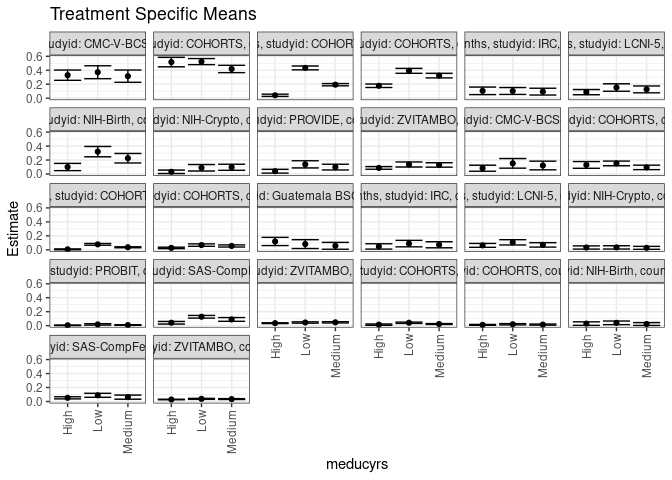

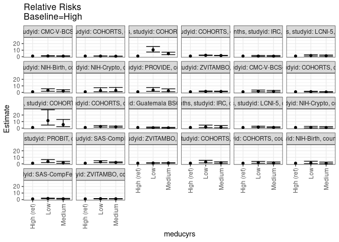

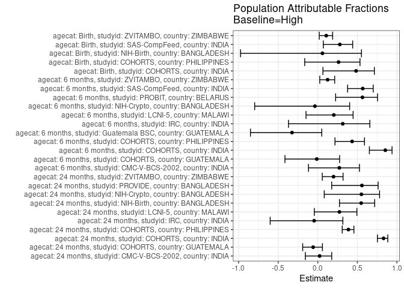

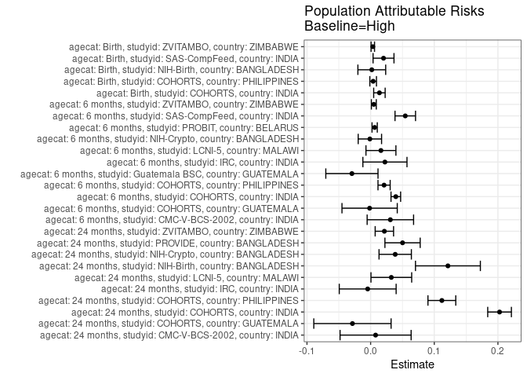

## Results Table

### Parameter: TSM

| agecat | studyid | country | intervention_level | baseline_level | estimate | ci_lower | ci_upper |
| --- | --- | --- | --- | --- | --- | --- | --- |
| Birth | COHORTS | INDIA | High | NA | 0.0147493 | 0.0056745 | 0.0238240 |
| Birth | COHORTS | INDIA | Low | NA | 0.0415718 | 0.0322348 | 0.0509087 |
| Birth | COHORTS | INDIA | Medium | NA | 0.0237239 | 0.0180682 | 0.0293797 |
| Birth | COHORTS | PHILIPPINES | High | NA | 0.0111206 | 0.0051082 | 0.0171330 |
| Birth | COHORTS | PHILIPPINES | Low | NA | 0.0200000 | 0.0108520 | 0.0291480 |
| Birth | COHORTS | PHILIPPINES | Medium | NA | 0.0152905 | 0.0076107 | 0.0229703 |
| Birth | NIH-Birth | BANGLADESH | High | NA | 0.0294118 | 0.0039927 | 0.0548308 |
| Birth | NIH-Birth | BANGLADESH | Low | NA | 0.0401786 | 0.0144406 | 0.0659165 |
| Birth | NIH-Birth | BANGLADESH | Medium | NA | 0.0233645 | 0.0031090 | 0.0436200 |
| Birth | SAS-CompFeed | INDIA | High | NA | 0.0524194 | 0.0369617 | 0.0678771 |
| Birth | SAS-CompFeed | INDIA | Low | NA | 0.0885860 | 0.0600275 | 0.1171446 |
| Birth | SAS-CompFeed | INDIA | Medium | NA | 0.0623501 | 0.0328535 | 0.0918467 |
| Birth | ZVITAMBO | ZIMBABWE | High | NA | 0.0284764 | 0.0247157 | 0.0322371 |
| Birth | ZVITAMBO | ZIMBABWE | Low | NA | 0.0377747 | 0.0308499 | 0.0446995 |
| Birth | ZVITAMBO | ZIMBABWE | Medium | NA | 0.0344224 | 0.0283192 | 0.0405256 |
| 6 months | CMC-V-BCS-2002 | INDIA | High | NA | 0.0828025 | 0.0396366 | 0.1259684 |
| 6 months | CMC-V-BCS-2002 | INDIA | Low | NA | 0.1523810 | 0.0835461 | 0.2212158 |
| 6 months | CMC-V-BCS-2002 | INDIA | Medium | NA | 0.1214953 | 0.0595088 | 0.1834819 |
| 6 months | COHORTS | GUATEMALA | High | NA | 0.1297297 | 0.0812860 | 0.1781734 |
| 6 months | COHORTS | GUATEMALA | Low | NA | 0.1514477 | 0.1182717 | 0.1846236 |
| 6 months | COHORTS | GUATEMALA | Medium | NA | 0.0943396 | 0.0621962 | 0.1264831 |
| 6 months | COHORTS | INDIA | High | NA | 0.0067935 | 0.0008586 | 0.0127284 |
| 6 months | COHORTS | INDIA | Low | NA | 0.0782217 | 0.0657358 | 0.0907077 |
| 6 months | COHORTS | INDIA | Medium | NA | 0.0368966 | 0.0300351 | 0.0437580 |
| 6 months | COHORTS | PHILIPPINES | High | NA | 0.0276134 | 0.0175258 | 0.0377010 |
| 6 months | COHORTS | PHILIPPINES | Low | NA | 0.0677966 | 0.0506492 | 0.0849440 |
| 6 months | COHORTS | PHILIPPINES | Medium | NA | 0.0552995 | 0.0400914 | 0.0705077 |
| 6 months | Guatemala BSC | GUATEMALA | High | NA | 0.1196581 | 0.0607416 | 0.1785747 |
| 6 months | Guatemala BSC | GUATEMALA | Low | NA | 0.0821918 | 0.0190725 | 0.1453111 |
| 6 months | Guatemala BSC | GUATEMALA | Medium | NA | 0.0574713 | 0.0084769 | 0.1064657 |
| 6 months | IRC | INDIA | High | NA | 0.0487805 | 0.0106657 | 0.0868952 |
| 6 months | IRC | INDIA | Low | NA | 0.0890411 | 0.0427870 | 0.1352952 |
| 6 months | IRC | INDIA | Medium | NA | 0.0724638 | 0.0291557 | 0.1157718 |
| 6 months | LCNI-5 | MALAWI | High | NA | 0.0637584 | 0.0360016 | 0.0915152 |
| 6 months | LCNI-5 | MALAWI | Low | NA | 0.1072797 | 0.0697123 | 0.1448471 |
| 6 months | LCNI-5 | MALAWI | Medium | NA | 0.0708661 | 0.0392901 | 0.1024421 |
| 6 months | NIH-Crypto | BANGLADESH | High | NA | 0.0333333 | 0.0106073 | 0.0560594 |
| 6 months | NIH-Crypto | BANGLADESH | Low | NA | 0.0349345 | 0.0111365 | 0.0587325 |
| 6 months | NIH-Crypto | BANGLADESH | Medium | NA | 0.0284553 | 0.0076632 | 0.0492473 |
| 6 months | PROBIT | BELARUS | High | NA | 0.0048927 | 0.0009804 | 0.0088050 |
| 6 months | PROBIT | BELARUS | Low | NA | 0.0177211 | 0.0079019 | 0.0275402 |
| 6 months | PROBIT | BELARUS | Medium | NA | 0.0085791 | 0.0039329 | 0.0132253 |
| 6 months | SAS-CompFeed | INDIA | High | NA | 0.0413793 | 0.0226362 | 0.0601225 |
| 6 months | SAS-CompFeed | INDIA | Low | NA | 0.1273032 | 0.1083867 | 0.1462196 |
| 6 months | SAS-CompFeed | INDIA | Medium | NA | 0.0890869 | 0.0621624 | 0.1160113 |
| 6 months | ZVITAMBO | ZIMBABWE | High | NA | 0.0355168 | 0.0302263 | 0.0408073 |
| 6 months | ZVITAMBO | ZIMBABWE | Low | NA | 0.0451253 | 0.0355220 | 0.0547287 |
| 6 months | ZVITAMBO | ZIMBABWE | Medium | NA | 0.0477294 | 0.0387340 | 0.0567248 |
| 24 months | CMC-V-BCS-2002 | INDIA | High | NA | 0.3291139 | 0.2557465 | 0.4024813 |
| 24 months | CMC-V-BCS-2002 | INDIA | Low | NA | 0.3714286 | 0.2788832 | 0.4639739 |
| 24 months | CMC-V-BCS-2002 | INDIA | Medium | NA | 0.3148148 | 0.2271039 | 0.4025258 |
| 24 months | COHORTS | GUATEMALA | High | NA | 0.5167464 | 0.4489656 | 0.5845272 |
| 24 months | COHORTS | GUATEMALA | Low | NA | 0.5237154 | 0.4801783 | 0.5672525 |
| 24 months | COHORTS | GUATEMALA | Medium | NA | 0.4181287 | 0.3658278 | 0.4704295 |
| 24 months | COHORTS | INDIA | High | NA | 0.0411184 | 0.0253333 | 0.0569036 |
| 24 months | COHORTS | INDIA | Low | NA | 0.4331761 | 0.4059420 | 0.4604102 |
| 24 months | COHORTS | INDIA | Medium | NA | 0.1928387 | 0.1767759 | 0.2089014 |
| 24 months | COHORTS | PHILIPPINES | High | NA | 0.1772429 | 0.1524810 | 0.2020048 |
| 24 months | COHORTS | PHILIPPINES | Low | NA | 0.3911290 | 0.3560560 | 0.4262020 |
| 24 months | COHORTS | PHILIPPINES | Medium | NA | 0.3227446 | 0.2900741 | 0.3554151 |
| 24 months | IRC | INDIA | High | NA | 0.1048387 | 0.0508528 | 0.1588246 |
| 24 months | IRC | INDIA | Low | NA | 0.1027397 | 0.0534301 | 0.1520493 |
| 24 months | IRC | INDIA | Medium | NA | 0.0935252 | 0.0450617 | 0.1419886 |
| 24 months | LCNI-5 | MALAWI | High | NA | 0.0863636 | 0.0492128 | 0.1235145 |
| 24 months | LCNI-5 | MALAWI | Low | NA | 0.1525424 | 0.0995278 | 0.2055570 |
| 24 months | LCNI-5 | MALAWI | Medium | NA | 0.1257143 | 0.0765525 | 0.1748761 |
| 24 months | NIH-Birth | BANGLADESH | High | NA | 0.1000000 | 0.0483697 | 0.1516303 |
| 24 months | NIH-Birth | BANGLADESH | Low | NA | 0.3202614 | 0.2462443 | 0.3942786 |
| 24 months | NIH-Birth | BANGLADESH | Medium | NA | 0.2260274 | 0.1581036 | 0.2939512 |
| 24 months | NIH-Crypto | BANGLADESH | High | NA | 0.0314136 | 0.0066518 | 0.0561754 |
| 24 months | NIH-Crypto | BANGLADESH | Low | NA | 0.0890411 | 0.0427988 | 0.1352834 |
| 24 months | NIH-Crypto | BANGLADESH | Medium | NA | 0.0960452 | 0.0525946 | 0.1394958 |
| 24 months | PROVIDE | BANGLADESH | High | NA | 0.0398010 | 0.0127518 | 0.0668501 |
| 24 months | PROVIDE | BANGLADESH | Low | NA | 0.1379310 | 0.0866506 | 0.1892114 |
| 24 months | PROVIDE | BANGLADESH | Medium | NA | 0.0985222 | 0.0574904 | 0.1395540 |
| 24 months | ZVITAMBO | ZIMBABWE | High | NA | 0.0870070 | 0.0681862 | 0.1058277 |
| 24 months | ZVITAMBO | ZIMBABWE | Low | NA | 0.1362319 | 0.1000235 | 0.1724403 |
| 24 months | ZVITAMBO | ZIMBABWE | Medium | NA | 0.1296296 | 0.0979454 | 0.1613138 |

### Parameter: E(Y)

| agecat | studyid | country | intervention_level | baseline_level | estimate | ci_lower | ci_upper |
| --- | --- | --- | --- | --- | --- | --- | --- |
| Birth | COHORTS | INDIA | NA | NA | 0.0285660 | 0.0240448 | 0.0330871 |
| Birth | COHORTS | PHILIPPINES | NA | NA | 0.0150820 | 0.0107558 | 0.0194081 |
| Birth | NIH-Birth | BANGLADESH | NA | NA | 0.0312500 | 0.0174085 | 0.0450915 |
| Birth | SAS-CompFeed | INDIA | NA | NA | 0.0726837 | 0.0523147 | 0.0930527 |
| Birth | ZVITAMBO | ZIMBABWE | NA | NA | 0.0319018 | 0.0289755 | 0.0348282 |
| 6 months | CMC-V-BCS-2002 | INDIA | NA | NA | 0.1138211 | 0.0813725 | 0.1462698 |
| 6 months | COHORTS | GUATEMALA | NA | NA | 0.1281513 | 0.1069071 | 0.1493954 |
| 6 months | COHORTS | INDIA | NA | NA | 0.0463699 | 0.0407674 | 0.0519723 |
| 6 months | COHORTS | PHILIPPINES | NA | NA | 0.0487445 | 0.0406327 | 0.0568562 |
| 6 months | Guatemala BSC | GUATEMALA | NA | NA | 0.0902527 | 0.0564475 | 0.1240580 |
| 6 months | IRC | INDIA | NA | NA | 0.0712531 | 0.0462303 | 0.0962759 |
| 6 months | LCNI-5 | MALAWI | NA | NA | 0.0799508 | 0.0612962 | 0.0986054 |
| 6 months | NIH-Crypto | BANGLADESH | NA | NA | 0.0321678 | 0.0192256 | 0.0451101 |
| 6 months | PROBIT | BELARUS | NA | NA | 0.0112310 | 0.0054733 | 0.0169886 |
| 6 months | SAS-CompFeed | INDIA | NA | NA | 0.0958084 | 0.0774939 | 0.1141229 |
| 6 months | ZVITAMBO | ZIMBABWE | NA | NA | 0.0405546 | 0.0363986 | 0.0447105 |
| 24 months | CMC-V-BCS-2002 | INDIA | NA | NA | 0.3369272 | 0.2887662 | 0.3850883 |
| 24 months | COHORTS | GUATEMALA | NA | NA | 0.4881741 | 0.4580257 | 0.5183225 |
| 24 months | COHORTS | INDIA | NA | NA | 0.2436875 | 0.2306994 | 0.2566756 |
| 24 months | COHORTS | PHILIPPINES | NA | NA | 0.2891616 | 0.2711872 | 0.3071359 |
| 24 months | IRC | INDIA | NA | NA | 0.1002445 | 0.0711031 | 0.1293859 |
| 24 months | LCNI-5 | MALAWI | NA | NA | 0.1188811 | 0.0923348 | 0.1454274 |
| 24 months | NIH-Birth | BANGLADESH | NA | NA | 0.2214452 | 0.1821080 | 0.2607825 |
| 24 months | NIH-Crypto | BANGLADESH | NA | NA | 0.0700389 | 0.0479542 | 0.0921236 |
| 24 months | PROVIDE | BANGLADESH | NA | NA | 0.0899654 | 0.0666186 | 0.1133122 |
| 24 months | ZVITAMBO | ZIMBABWE | NA | NA | 0.1086028 | 0.0935351 | 0.1236705 |

### Parameter: RR

| agecat | studyid | country | intervention_level | baseline_level | estimate | ci_lower | ci_upper |
| --- | --- | --- | --- | --- | --- | --- | --- |
| Birth | COHORTS | INDIA | High | High | 1.0000000 | 1.0000000 | 1.0000000 |
| Birth | COHORTS | INDIA | Low | High | 2.8185649 | 1.4641121 | 5.4260247 |
| Birth | COHORTS | INDIA | Medium | High | 1.6084831 | 0.8314811 | 3.1115776 |
| Birth | COHORTS | PHILIPPINES | High | High | 1.0000000 | 1.0000000 | 1.0000000 |
| Birth | COHORTS | PHILIPPINES | Low | High | 1.7984615 | 0.8858124 | 3.6514095 |
| Birth | COHORTS | PHILIPPINES | Medium | High | 1.3749706 | 0.6573636 | 2.8759489 |
| Birth | NIH-Birth | BANGLADESH | High | High | 1.0000000 | 1.0000000 | 1.0000000 |
| Birth | NIH-Birth | BANGLADESH | Low | High | 1.3660714 | 0.4658790 | 4.0056565 |
| Birth | NIH-Birth | BANGLADESH | Medium | High | 0.7943925 | 0.2335614 | 2.7018994 |
| Birth | SAS-CompFeed | INDIA | High | High | 1.0000000 | 1.0000000 | 1.0000000 |
| Birth | SAS-CompFeed | INDIA | Low | High | 1.6899489 | 1.2364493 | 2.3097811 |
| Birth | SAS-CompFeed | INDIA | Medium | High | 1.1894484 | 0.7448073 | 1.8995350 |
| Birth | ZVITAMBO | ZIMBABWE | High | High | 1.0000000 | 1.0000000 | 1.0000000 |
| Birth | ZVITAMBO | ZIMBABWE | Low | High | 1.3265283 | 1.0582649 | 1.6627948 |
| Birth | ZVITAMBO | ZIMBABWE | Medium | High | 1.2088054 | 0.9690401 | 1.5078949 |
| 6 months | CMC-V-BCS-2002 | INDIA | High | High | 1.0000000 | 1.0000000 | 1.0000000 |
| 6 months | CMC-V-BCS-2002 | INDIA | Low | High | 1.8402930 | 0.9232314 | 3.6682878 |
| 6 months | CMC-V-BCS-2002 | INDIA | Medium | High | 1.4672897 | 0.7075042 | 3.0430054 |
| 6 months | COHORTS | GUATEMALA | High | High | 1.0000000 | 1.0000000 | 1.0000000 |
| 6 months | COHORTS | GUATEMALA | Low | High | 1.1674091 | 0.7571874 | 1.7998765 |
| 6 months | COHORTS | GUATEMALA | Medium | High | 0.7272013 | 0.4386494 | 1.2055680 |
| 6 months | COHORTS | INDIA | High | High | 1.0000000 | 1.0000000 | 1.0000000 |
| 6 months | COHORTS | INDIA | Low | High | 11.5142375 | 4.7374574 | 27.9849831 |
| 6 months | COHORTS | INDIA | Medium | High | 5.4311724 | 2.2232285 | 13.2679273 |
| 6 months | COHORTS | PHILIPPINES | High | High | 1.0000000 | 1.0000000 | 1.0000000 |
| 6 months | COHORTS | PHILIPPINES | Low | High | 2.4552058 | 1.5744151 | 3.8287460 |
| 6 months | COHORTS | PHILIPPINES | Medium | High | 2.0026333 | 1.2676959 | 3.1636453 |
| 6 months | Guatemala BSC | GUATEMALA | High | High | 1.0000000 | 1.0000000 | 1.0000000 |
| 6 months | Guatemala BSC | GUATEMALA | Low | High | 0.6868885 | 0.2758706 | 1.7102790 |
| 6 months | Guatemala BSC | GUATEMALA | Medium | High | 0.4802956 | 0.1794552 | 1.2854673 |
| 6 months | IRC | INDIA | High | High | 1.0000000 | 1.0000000 | 1.0000000 |
| 6 months | IRC | INDIA | Low | High | 1.8253425 | 0.7142605 | 4.6647899 |
| 6 months | IRC | INDIA | Medium | High | 1.4855072 | 0.5554590 | 3.9728075 |
| 6 months | LCNI-5 | MALAWI | High | High | 1.0000000 | 1.0000000 | 1.0000000 |
| 6 months | LCNI-5 | MALAWI | Low | High | 1.6825973 | 0.9623597 | 2.9418663 |
| 6 months | LCNI-5 | MALAWI | Medium | High | 1.1114795 | 0.5961566 | 2.0722519 |
| 6 months | NIH-Crypto | BANGLADESH | High | High | 1.0000000 | 1.0000000 | 1.0000000 |
| 6 months | NIH-Crypto | BANGLADESH | Low | High | 1.0480349 | 0.3997689 | 2.7475307 |
| 6 months | NIH-Crypto | BANGLADESH | Medium | High | 0.8536585 | 0.3142418 | 2.3190194 |
| 6 months | PROBIT | BELARUS | High | High | 1.0000000 | 1.0000000 | 1.0000000 |
| 6 months | PROBIT | BELARUS | Low | High | 3.6219141 | 1.9891646 | 6.5948596 |
| 6 months | PROBIT | BELARUS | Medium | High | 1.7534337 | 0.8078447 | 3.8058422 |
| 6 months | SAS-CompFeed | INDIA | High | High | 1.0000000 | 1.0000000 | 1.0000000 |
| 6 months | SAS-CompFeed | INDIA | Low | High | 3.0764936 | 1.9394695 | 4.8801040 |
| 6 months | SAS-CompFeed | INDIA | Medium | High | 2.1529324 | 1.5557700 | 2.9793081 |
| 6 months | ZVITAMBO | ZIMBABWE | High | High | 1.0000000 | 1.0000000 | 1.0000000 |
| 6 months | ZVITAMBO | ZIMBABWE | Low | High | 1.2705353 | 0.9798765 | 1.6474115 |
| 6 months | ZVITAMBO | ZIMBABWE | Medium | High | 1.3438535 | 1.0568748 | 1.7087571 |
| 24 months | CMC-V-BCS-2002 | INDIA | High | High | 1.0000000 | 1.0000000 | 1.0000000 |
| 24 months | CMC-V-BCS-2002 | INDIA | Low | High | 1.1285714 | 0.8078518 | 1.5766178 |
| 24 months | CMC-V-BCS-2002 | INDIA | Medium | High | 0.9565527 | 0.6694908 | 1.3666999 |
| 24 months | COHORTS | GUATEMALA | High | High | 1.0000000 | 1.0000000 | 1.0000000 |
| 24 months | COHORTS | GUATEMALA | Low | High | 1.0134863 | 0.8677107 | 1.1837523 |
| 24 months | COHORTS | GUATEMALA | Medium | High | 0.8091564 | 0.6750210 | 0.9699462 |
| 24 months | COHORTS | INDIA | High | High | 1.0000000 | 1.0000000 | 1.0000000 |
| 24 months | COHORTS | INDIA | Low | High | 10.5348428 | 7.1397598 | 15.5443481 |
| 24 months | COHORTS | INDIA | Medium | High | 4.6898361 | 3.1663198 | 6.9464121 |
| 24 months | COHORTS | PHILIPPINES | High | High | 1.0000000 | 1.0000000 | 1.0000000 |
| 24 months | COHORTS | PHILIPPINES | Low | High | 2.2067403 | 1.8691958 | 2.6052396 |
| 24 months | COHORTS | PHILIPPINES | Medium | High | 1.8209171 | 1.5323704 | 2.1637973 |
| 24 months | IRC | INDIA | High | High | 1.0000000 | 1.0000000 | 1.0000000 |
| 24 months | IRC | INDIA | Low | High | 0.9799789 | 0.4847353 | 1.9812023 |
| 24 months | IRC | INDIA | Medium | High | 0.8920863 | 0.4296741 | 1.8521432 |
| 24 months | LCNI-5 | MALAWI | High | High | 1.0000000 | 1.0000000 | 1.0000000 |
| 24 months | LCNI-5 | MALAWI | Low | High | 1.7662801 | 1.0159844 | 3.0706628 |
| 24 months | LCNI-5 | MALAWI | Medium | High | 1.4556391 | 0.8139073 | 2.6033495 |
| 24 months | NIH-Birth | BANGLADESH | High | High | 1.0000000 | 1.0000000 | 1.0000000 |
| 24 months | NIH-Birth | BANGLADESH | Low | High | 3.2026144 | 1.8190192 | 5.6386095 |
| 24 months | NIH-Birth | BANGLADESH | Medium | High | 2.2602740 | 1.2437058 | 4.1077549 |
| 24 months | NIH-Crypto | BANGLADESH | High | High | 1.0000000 | 1.0000000 | 1.0000000 |
| 24 months | NIH-Crypto | BANGLADESH | Low | High | 2.8344749 | 1.1028551 | 7.2849534 |
| 24 months | NIH-Crypto | BANGLADESH | Medium | High | 3.0574388 | 1.2321130 | 7.5869111 |
| 24 months | PROVIDE | BANGLADESH | High | High | 1.0000000 | 1.0000000 | 1.0000000 |
| 24 months | PROVIDE | BANGLADESH | Low | High | 3.4655172 | 1.5971258 | 7.5196390 |
| 24 months | PROVIDE | BANGLADESH | Medium | High | 2.4753695 | 1.1155198 | 5.4929137 |
| 24 months | ZVITAMBO | ZIMBABWE | High | High | 1.0000000 | 1.0000000 | 1.0000000 |
| 24 months | ZVITAMBO | ZIMBABWE | Low | High | 1.5657585 | 1.1114719 | 2.2057235 |
| 24 months | ZVITAMBO | ZIMBABWE | Medium | High | 1.4898765 | 1.0749767 | 2.0649118 |

### Parameter: PAR

| agecat | studyid | country | intervention_level | baseline_level | estimate | ci_lower | ci_upper |
| --- | --- | --- | --- | --- | --- | --- | --- |
| Birth | COHORTS | INDIA | High | NA | 0.0138167 | 0.0047954 | 0.0228379 |
| Birth | COHORTS | PHILIPPINES | High | NA | 0.0039614 | -0.0012496 | 0.0091723 |
| Birth | NIH-Birth | BANGLADESH | High | NA | 0.0018382 | -0.0199882 | 0.0236647 |
| Birth | SAS-CompFeed | INDIA | High | NA | 0.0202644 | 0.0038212 | 0.0367075 |
| Birth | ZVITAMBO | ZIMBABWE | High | NA | 0.0034255 | 0.0007118 | 0.0061392 |
| 6 months | CMC-V-BCS-2002 | INDIA | High | NA | 0.0310186 | -0.0054594 | 0.0674965 |
| 6 months | COHORTS | GUATEMALA | High | NA | -0.0015785 | -0.0450067 | 0.0418498 |
| 6 months | COHORTS | INDIA | High | NA | 0.0395764 | 0.0320244 | 0.0471283 |
| 6 months | COHORTS | PHILIPPINES | High | NA | 0.0211310 | 0.0115731 | 0.0306889 |
| 6 months | Guatemala BSC | GUATEMALA | High | NA | -0.0294054 | -0.0704132 | 0.0116024 |
| 6 months | IRC | INDIA | High | NA | 0.0224726 | -0.0121801 | 0.0571253 |
| 6 months | LCNI-5 | MALAWI | High | NA | 0.0161924 | -0.0073371 | 0.0397219 |
| 6 months | NIH-Crypto | BANGLADESH | High | NA | -0.0011655 | -0.0195299 | 0.0171989 |
| 6 months | PROBIT | BELARUS | High | NA | 0.0063382 | 0.0022081 | 0.0104684 |
| 6 months | SAS-CompFeed | INDIA | High | NA | 0.0544291 | 0.0383084 | 0.0705498 |
| 6 months | ZVITAMBO | ZIMBABWE | High | NA | 0.0050378 | 0.0011843 | 0.0088913 |
| 24 months | CMC-V-BCS-2002 | INDIA | High | NA | 0.0078133 | -0.0480210 | 0.0636476 |
| 24 months | COHORTS | GUATEMALA | High | NA | -0.0285723 | -0.0892875 | 0.0321429 |
| 24 months | COHORTS | INDIA | High | NA | 0.2025690 | 0.1839764 | 0.2211617 |
| 24 months | COHORTS | PHILIPPINES | High | NA | 0.1119187 | 0.0900599 | 0.1337775 |
| 24 months | IRC | INDIA | High | NA | -0.0045942 | -0.0492763 | 0.0400878 |
| 24 months | LCNI-5 | MALAWI | High | NA | 0.0325175 | 0.0005298 | 0.0645051 |
| 24 months | NIH-Birth | BANGLADESH | High | NA | 0.1214452 | 0.0704792 | 0.1724113 |
| 24 months | NIH-Crypto | BANGLADESH | High | NA | 0.0386253 | 0.0132246 | 0.0640260 |
| 24 months | PROVIDE | BANGLADESH | High | NA | 0.0501644 | 0.0224541 | 0.0778747 |
| 24 months | ZVITAMBO | ZIMBABWE | High | NA | 0.0215958 | 0.0071506 | 0.0360411 |

### Parameter: PAF

| agecat | studyid | country | intervention_level | baseline_level | estimate | ci_lower | ci_upper |
| --- | --- | --- | --- | --- | --- | --- | --- |
| Birth | COHORTS | INDIA | High | NA | 0.4836768 | 0.0648619 | 0.7149195 |
| Birth | COHORTS | PHILIPPINES | High | NA | 0.2626548 | -0.1651706 | 0.5333920 |
| Birth | NIH-Birth | BANGLADESH | High | NA | 0.0588235 | -0.9758330 | 0.5516761 |
| Birth | SAS-CompFeed | INDIA | High | NA | 0.2788018 | 0.0696446 | 0.4409376 |
| Birth | ZVITAMBO | ZIMBABWE | High | NA | 0.1073750 | 0.0187178 | 0.1880221 |
| 6 months | CMC-V-BCS-2002 | INDIA | High | NA | 0.2725205 | -0.1181970 | 0.5267144 |
| 6 months | COHORTS | GUATEMALA | High | NA | -0.0123172 | -0.4148127 | 0.2756736 |
| 6 months | COHORTS | INDIA | High | NA | 0.8534936 | 0.6522116 | 0.9382840 |
| 6 months | COHORTS | PHILIPPINES | High | NA | 0.4335067 | 0.2172768 | 0.5900023 |
| 6 months | Guatemala BSC | GUATEMALA | High | NA | -0.3258120 | -0.8505799 | 0.0501478 |
| 6 months | IRC | INDIA | High | NA | 0.3153911 | -0.3699702 | 0.6578835 |
| 6 months | LCNI-5 | MALAWI | High | NA | 0.2025297 | -0.1486756 | 0.4463546 |
| 6 months | NIH-Crypto | BANGLADESH | High | NA | -0.0362319 | -0.7974273 | 0.4026037 |
| 6 months | PROBIT | BELARUS | High | NA | 0.5643530 | 0.2256841 | 0.7548955 |
| 6 months | SAS-CompFeed | INDIA | High | NA | 0.5681034 | 0.3771488 | 0.7005150 |
| 6 months | ZVITAMBO | ZIMBABWE | High | NA | 0.1242225 | 0.0247386 | 0.2135582 |
| 24 months | CMC-V-BCS-2002 | INDIA | High | NA | 0.0231899 | -0.1574128 | 0.1756113 |
| 24 months | COHORTS | GUATEMALA | High | NA | -0.0585290 | -0.1905625 | 0.0588620 |
| 24 months | COHORTS | INDIA | High | NA | 0.8312658 | 0.7537135 | 0.8843979 |
| 24 months | COHORTS | PHILIPPINES | High | NA | 0.3870455 | 0.3087887 | 0.4564422 |
| 24 months | IRC | INDIA | High | NA | -0.0458301 | -0.6013753 | 0.3169868 |
| 24 months | LCNI-5 | MALAWI | High | NA | 0.2735294 | -0.0440139 | 0.4944900 |
| 24 months | NIH-Birth | BANGLADESH | High | NA | 0.5484211 | 0.2742037 | 0.7190347 |
| 24 months | NIH-Crypto | BANGLADESH | High | NA | 0.5514834 | 0.0815919 | 0.7809611 |
| 24 months | PROVIDE | BANGLADESH | High | NA | 0.5575966 | 0.1758141 | 0.7625284 |
| 24 months | ZVITAMBO | ZIMBABWE | High | NA | 0.1988516 | 0.0569014 | 0.3194363 |